# FRidh's blog **Discovery consists of seeing what everybody has seen and thinking what nobody has thought -- Albert Szent-Gyorgyi**

## Finished PhD

1. Back in September, I defended my PhD thesis. The PDF can be [found](http://publications.lib.chalmers.se/records/fulltext/251306/251306.pdf) in the Chalmers library. Furthermore, I made available a [routine](https://github.com/FRidh/phd_thesis) to build the PDF from source, including the majority of the simulations. This is done using the [Nix package manager](https://nixos.org/nix/).

## Urban Sound Planning Symposium

2. On the 15th and 16th of September the [Urban Sound Planning Symposium](http://www.muellerbbm.com/events/seminars-and-workshops/urban-sound-planning/) took place at Muller-BBM in Planegg, Germany. This occassion also marked the end of the SONORUS project. At the symposium we mostly looked back at what we've achieved these last three years. There was a short poster session and after the event was over we got our "Urban Sound Planner" certificates. Finally I have something to hang up next to my shoe-lacing certificate.

## Research visit to NASA Langley Research Center

3. In March I was at NASA Langley Research Center in Hampton, Virginia, for a four week research visit. The goal of the visit was to exchange knowledge on auralization of aircraft and atmospheric turbulence modeling. During this period we improved a model I had been working on and demonstrated that this model can be incorporated in the NASA Auralization Framework (NAF).

   I was staying with a nice family in the town of Poquoson. While I've grown up nearby the coast I had never lived this close to the waterside before. I like the strong wind and smell of salt. It was an interesting experience living in this part of the United States and quite unlike the places I've lived in so far.

## SONORUS update

4. It's been quite a while I've written on this blog about SONORUS, or anything else in fact. A lot has happened since then.

   In October and November I was at Chalmers again for 6 weeks, following some courses. Furthermore, we had the school on Auralization and Visualization as well as a workshop around the Gothenburg test site.

   In January we had another SONORUS workshop, this time in Rome. It was my first time in Rome and I was glad to finally see the Colosseum as well as the Apostolic Palace.

   In March I went to the U.S. for a four week research visit to NASA Langley Research Center. I wrote more about that in another post.

   And just a couple of days ago we had another workshop, this time in Antwerp, Belgium.

   The SONORUS project is almost over. In September there will be a final meeting in Munich. More about that later...

## Synthesis of aircraft emission and propagation

5. *This is a repost of a [post of mine](https://sonorusfp7.wordpress.com/2015/08/21/synthesis-of-aircraft-emission-and-propagation) at the SONORUS blog*

   In an earlier post I gave an outline of my project, and mentioned that I am currently working on an aircraft emission model for auralization. Since then I developed a fully automated method to extract features from aircraft recordings.

   The method is roughly as follows:
   - Backpropagate from source to receiver in time-domain, undoing the Doppler shift, atmospheric attenuation and spreading. The ground effect is ignored for now. We now have a signal that roughly corresponds to what is emitted from the airplane.
   - Determine fundamental frequency. An aircraft spectrum consists mostly of noise and tones, which are mostly harmonics. Knowing the fundamental frequency, allows you to determine the power of not only the fundamental, but also of each harmonic.
   - And that is the final step. Determine power of the tones, and consider the rest of the spectrum as noise.

   The plan is now to determine these features from a large amount of events and develop a basic emission model. But before then, its important to already ask the following question. Are these features sufficient to create a realistic emission signal? Or, even better, are these features, taking into account the developed propagation model, providing a realistic signal at the receiver? Does, what you hear, really sound like an aircraft? That's in the end what we're after, right.

## Synthesis of emission

   To test whether the obtained features are sufficient to reproduce a realistic auralization, I considered a couple of events, and extracted the features for each. I synthesized an emission signal by summing all these time-varying components (about 200 tones and 30 1/3-octave bands), linearly interpolating the samples (features were obtained every second) and smoothing the interpolated components.

   [Click here](https://zenodo.org/record/28815/files/synthesis.wav) to listen to a synthesis of the emission. It's an Airbus A320 taking of from Zurich Airport.

   The first part of the fragment you can hear the tonal components quite clearly but in the latter part noise takes over. This is due to the directivity of the components; tones generated by the fan blades radiate mostly forward.

   For comparison, [here](https://zenodo.org/record/28815/files/reverted.wav) is the backpropagated signal. You'll notice it sounds very different. This is because the (unwanted) ground effect is still in it. And because of it, it sounds much more already like an actual aircraft fly-over!

## At the receiver

   So, let's listen now at a receiver at a height of 4 meters above the ground. When the aircraft is closest by, the distance is about 180 meters. Here are two fragments: [fragment A](https://zenodo.org/record/28815/files/recording.wav) and [fragment B](https://zenodo.org/record/28815/files/auralization.wav). One is a full auralization, the other is a recording. Can you hear which is which?

   *(hint: look at the URL in the top part of your browser if you want to know for sure)*

   There are two quite noticeable differences between the recording and the auralization. This specific auralization does not include the effects of turbulence, and the level of the blade passing frequency is lower than it should be.

## Euronoise slides

6. The [slides](http://dx.doi.org/10.5281/zenodo.18111) I used for my presentation at Euronoise 2015 can be found online at Zenodo. The [proceedings](http://dx.doi.org/10.5281/zenodo.15702) are also available.

## Swiss Air Force demonstrations in Duebendorf

7. The headquarters of the Swiss Air Force is located in Duebendorf, and the airstrip of the base is not that far from where I work. Often you can see paratroopers and helicopters or hear other aircraft take off.

   Occasionally, one of the [demonstration teams](https://en.wikipedia.org/wiki/Swiss_Air_Force#Air_demonstration_teams) practices. So far I've only seen the PC-7 Team, which use Swiss-manufactered [Pilatus PC-7](https://en.wikipedia.org/wiki/Pilatus_PC-7) turbo prop trainers. These aircraft can be quite noisy. Actually, it's not that the sound is very loud, it's just that the sound can be annoying. The propellors have a strong directivity and therefore, as they do their maneuvers, the level goes up and down.

   They don't practice that often, and their sessions generally don't last more than a couple of hours. Therefore, I can't really be bothered too much by it. If I hear them, and it bothers me, I just close my window or turn the music up a bit. But what astonishes me is that they actually do these activities above dense populated areas. Many people are living and working in the area. What if an accident occurs?

   I realize there aren't many places in Switzerland where they could build airstrips and do this kind of training without flying over someone's home. But flying over a dense area like this or flying over one or two farms is quite a difference. I am curious now to their risk assessment and how they've eventually decided to keep doing these activities here.

   To conclude, these activities can be noisy, and perhaps also dangerous. However, on a more positive note, they also provide good entertainment during your break!

## Development of an emission model

8. On June the 2nd I will present a paper, titled *Determining an Empirical Emission Model for the Auralization of Jet Aircraft*, at the Euronoise conference in Maastricht, The Netherlands. My presentation will be in the *Auralisation of urban sound* session. The conference is just a couple of weeks away from now, and I am still analysing and gathering results. Nevertheless, I thought it would be nice to give a bit of an insight on what I'm working on now and what I will present at Euronoise.

   ## Emission model for auralizations

   Currently I'm developing an emission model for jet aircraft that can be used for auralizations. Existing emission models for noise prediction generally predict sound pressure levels in 1/3-octaves. This works for noise prediction, however, for auralization a finer resolution is needed. Indeed, one needs to be able to model individual tones and in certain cases also modulations.

   At Empa we have in the past conducted measurements for the [sonAIR project](http://www.empa.ch/plugin/template/empa/647/133617/---/l=2/changeLang=true/lartid=133617/orga=/type=/theme=/bestellbar=/new_abt=/uacc=) resulting in a large dataset including audio recordings at multiple sites, cockpit data and flight track data. Colleagues of mine are using this dataset now to develop a next-generation emission model for noise prediction and I'm using this dataset to develop an emission model for auralizations.

   ## Analysis of an event

   Let's now have a look at one specific event and how I analyse such event. I've included the Python code I use for the analysis, so you get a better idea of how I'm working. To give you an idea, there is over 500 GB of audio recordings and several hundreds of MBs on other data. The audio is stored in a single `hdf5` file using [h5py](http://www.h5py.org/) and all other data in a [SQLite](https://www.sqlite.org/) database. All data is handled using the amazing [Blaze](http://blaze.pydata.org/) and [pandas](http://pandas.pydata.org/) modules.

   ```python
   from sonair.processing import *
   %matplotlib inline
   ```

   We begin by loading the data belonging to a combination of event (i.e. aircraft passage) and receiver and from a certain start and stop time. `start` and `stop` are here seconds relative to a certain event reference time. This reference time is the time at which the aircraft is closest to any of the receivers and turned out to be quite conventient to use.

   ```python
   event = '10_004_A320'
   receiver = 'A'
   start = -5.
   stop = +5.

   analysis = EventAnalysis(event, receiver, start, stop)
   ```

   We now have a nice object that gives easy access to all the data. For example, we can request the atmospheric pressure (in mbar) during that event

   ```python
   analysis.event.pressure
   ```

   ```
   977.39999999999998
   ```

   or the coordinates of the receiver (Swiss grid)

   ```python
   analysis.receiver.x, analysis.receiver.y, analysis.receiver.z
   ```

   ```
   (682692.67099999997, 257054.26800000001, 422.048)
   ```

   Obviously, we can also listen to the recording

   ```python
   from IPython.display import Audio
   Audio(data=analysis.recording_as_signal, rate=analysis.recording_as_signal.fs)
   ```

[interactive chart not shown]

   or look at the instantaneous pressure that was measured as a [pandas](http://pandas.pydata.org/) Series

   ```python
   analysis.recording.head()
   ```

   ```
   2013-09-02 07:25:41.050000       0.618678
   2013-09-02 07:25:41.050022676    0.577433
   2013-09-02 07:25:41.050045352    0.587744
   2013-09-02 07:25:41.050068028    0.659923
   2013-09-02 07:25:41.050090704    0.763036
   Name: signal, dtype: float64
   ```

   The above values show you the instantaneous sound pressure as function of time. Perhaps more interesting is to consider the sound pressure level as function of time

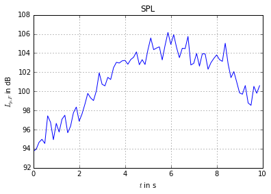

   ```python
   _ = analysis.recording_as_signal.plot_levels()
   ```

   or the spectrogram, showing the sound pressure not just as function of time, but also as function of frequency.

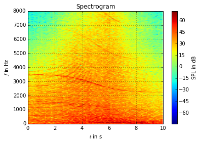

   ```python
   _ = analysis.recording_as_signal.spectrogram(ylim=(0.0, 8000.0))
   ```

   The spectrogram clearly shows the [Doppler shift](http://en.wikipedia.org/wiki/Doppler_effect). Also visible, though perhaps not so obvious with the current ranges, is that in the first couple of seconds tones are clearly visible and audible, however, in the latter they're almost gone. This is due to the directivity of the aircraft.

   The emission model needs to be able to predict the emission as function of several parameters, like velocity of the aircraft and/or thrust. What is received by the receiver however also depends on this directivity, i.e., the emission as function of the angles between source and receiver.

   ## Sound propagation

   As the sound waves travel from the source to the receiver several physical phenomena occur. First of all, the aircraft moves with a certain speed relative to the atmosphere, and this causes a Doppler shift. Then, in open spaces sound spreads out, in our case mostly spherically. Furthermore, due to relaxation processes the sound waves are attenuated. The receiver could move as well resulting in an additional Doppler shift. Luckily, we were using fixed microphones, so this is a problem we won't have to deal with.

   However, an unwanted effect that can occur for which correcting would be very difficult are contributions due to reflections. And unfortunately we had ground reflections. To make matters worse, atmospheric turbulence adds a bit of randomness to the propagation. Joy!

   ## Calculating back to the source

   In order to determine the actual emission of the aircraft we now have to undo these effects. This, however, is not that easy. I won't go into details regarding assumptions I made, nor the errors I would make, but instead just briefly explain what I did.

   Using meteorological information I could estimate the speed of sound and attenuation in the atmosphere. Together with positional information of the aircraft and receiver I could undo the time lag and thus Doppler shift (basically by doing the inverse of what I [posted earlier on the Doppler shift](http://www.fridh.nl/2015/02/01/auralization-doppler-effect/)) as well as attenuation due to air absorption. These operations are all applied directly to the audio recording. Let's listen to the result!

   ```python
   Audio(data=analysis.reverted_as_signal, rate=analysis.reverted_as_signal.fs)
   ```

[interactive chart not shown]

   This sounds quite different from the original recording! The Doppler shift is gone, as you can also see in the spectrogram

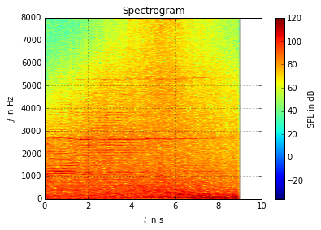

   ```python
   _ = analysis.reverted_as_signal.spectrogram(ylim=(0.0, 8000.0))
   ```

   and the level also doesn't change that much anymore over time either.

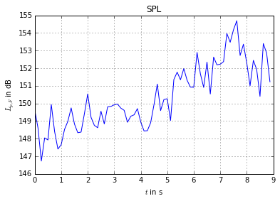

   ```python
   _ = analysis.reverted_as_signal.plot_levels()
   ```

   Unfortunately there was a click audible at the start. Fixing that is on my to-do list.

   ## Investiging the emission spectrum

   Now that we've calculated back to the source it is time to investigate the emission. The power spectral density shows many peaks, and there seems to be a pattern in the recurrence. It looks as if there is some constant spacing between the tones.

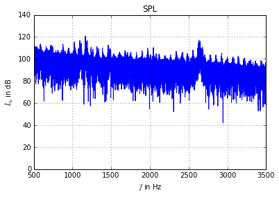

   ```python
   fig = analysis.reverted_as_signal.plot_power_spectrum(xscale='linear', xlim=(500, 3500))
   ```

   Maybe we can check if this is the case and determine this spacing? Luckily, we can. Using cepstral analysis, or more specifically, using the *complex cepstrum*, we can determine the spacing between these recurrences. I won't show any further how I use the complex cepstrum but instead go straight to the result. The spacing corresponds to the frequency at which the engine's shaft rotates. This frequency is the $N_1$ frequency and is determined to be

   ```python
   analysis.N1
   ```

   ```
   73.13432836293677
   ```

   The tones that you see and hear are multiples of this $N_1$ frequency and are called [Buzz-Saw tones](http://www.southampton.ac.uk/engineering/research/projects/buzz_saw_noise_and_non_linear_acoustics.page). However, one very strong peak is visible at

   ```python
   blades = 36
   analysis.N1 * blades
   ```

   ```
   2632.8358210657238
   ```

   This is the blade passing frequency, which is obtained by multiplying $N_1$ with the amount of blades of the fan. Multiples of the blade passing frequency are also present and audible. The figure below shows again the power spectral density along with black and red lines representing respectively Buzz-Saw tones and multiples of the blade passing frequency.

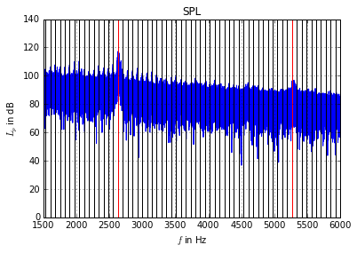

   ```python
   fig = analysis.reverted_as_signal.plot_power_spectrum(xscale='linear', xlim=(1500, 6000))
   for harmonic in analysis.N1_harmonics:
       fig.axes[0].axvline(harmonic, color='black')
   for harmonic in np.arange(1, 3)*analysis.N1*blades:
       fig.axes[0].axvline(harmonic, color='red')
   ```

   ## Extracting features

   The next step is to estimate the power of the tones and the noise for all events and receiver combinations and using those estimations along with estimations of velocity and thrust to develop an emission model. As mentioned before, this means taking into account the directivity and thus the orientation from source to receiver (or vice versa). The figure below shows the components of the unit vector pointing from receiver to source.

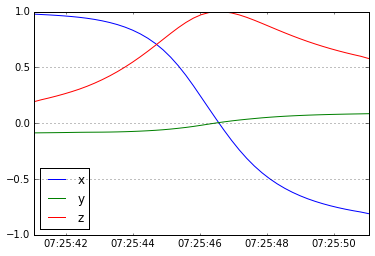

   ```python
   _ = analysis.orientation_receiver_to_source.ix[::10000].plot()
   ```

   Right now I'm writing the code needed to automatically extract the features. Hopefully, in a couple of days I can begin analysing the extracted features. I'm looking forward to that!

   ## Then what?

   After I've extracted the features and developed the initial model I plan on doing some preliminary listening tests in our lab at [Empa](http://www.empa.ch/plugin/template/empa/647/130651/---/l=3/changeLang=true/lartid=130651/orga=/type=/theme=/bestellbar=/new_abt=/uacc=) this summer. Depending on the results of those tests, I plan further listening tests in autumn at [SP](http://www.sp.se/)'s listening room, which features a 3rd order Ambisonics system. And after that? Well, then I think it's time to write my thesis!